# Assignment1

CHAN Yat Tin 3035869651 JIANG Rui 3035869637

# Question 1

Data Generating Process

Part a – Generate n=100 observations on the dependent variable Yi, the main regressor Di, and k=20 controls/covariates Xi,j,j=1,…,k, and then save it into a dataframe

```r
# Specify seed to ensure reproducibility
set.seed(12345)
dataset.data.frame_1 <- dgp_1(100, 20)
```

Part b – Using lm(), estimate the regression of Yi against Di only and report the standard error and p-value on the coefficient of Di

```r
reg_b <- lm(yi~di, data=dataset.data.frame_1)
summary(reg_b)
```

```
##
## Call:
## lm(formula = yi ~ di, data = dataset.data.frame_1)
##
## Residuals:
##      Min       1Q   Median       3Q      Max
## -2.33969 -0.66508  0.03443  0.71364  2.26962
##
## Coefficients:
##             Estimate Std. Error t value Pr(>|t|)
## (Intercept) -0.02503    0.09857  -0.254  0.80007
## di           1.30861    0.42435   3.084  0.00265 **
## ---
## Signif. codes:  0 '***' 0.001 '**' 0.01 '*' 0.05 '.' 0.1 ' ' 1
##
## Residual standard error: 0.9852 on 98 degrees of freedom
## Multiple R-squared:  0.08846,    Adjusted R-squared:  0.07916
## F-statistic:  9.51 on 1 and 98 DF,  p-value: 0.002655
```

The standard error and p-value on the coefficient of Di are 0.42435 and 0.00265 respectively.

Part c – Using lm(), estimate the regression of Yi against Di with all 20 controls included and report the standard error and p-value on the coefficient of Di Compare with the standard error and p-value in part (b). Discuss the differences and if they make sense

```r
reg_c= lm(yi~di+`xi,1`+`xi,2`+`xi,3`+`xi,4`+`xi,5`+`xi,6`+`xi,7`+`xi,8`+`xi,9`+`xi,10`+`xi,11`+`xi,12`+`xi,13`+`xi,14`+`xi,15`+`xi,16`+`xi,17`+`xi,18`+`xi,19`+`xi,20`, data=dataset.data.frame_1)
summary(reg_c)
```

```
##
## Call:
## lm(formula = yi ~ di + `xi,1` + `xi,2` + `xi,3` + `xi,4` + `xi,5` +
##     `xi,6` + `xi,7` + `xi,8` + `xi,9` + `xi,10` + `xi,11` + `xi,12` +
##     `xi,13` + `xi,14` + `xi,15` + `xi,16` + `xi,17` + `xi,18` +
##     `xi,19` + `xi,20`, data = dataset.data.frame_1)
##
## Residuals:
##      Min       1Q   Median       3Q      Max
## -2.46902 -0.50184 -0.04513  0.61456  1.63781
##
## Coefficients:
##             Estimate Std. Error t value Pr(>|t|)
## (Intercept)   0.0572     0.1122   0.510    0.612
## di           10.7047    10.5245   1.017    0.312
## `xi,1`       -0.7046     0.5334  -1.321    0.190
## `xi,2`       -0.5998     0.5227  -1.148    0.255
## `xi,3`       -0.5708     0.5266  -1.084    0.282
## `xi,4`       -0.5430     0.5409  -1.004    0.319
## `xi,5`       -0.4024     0.5330  -0.755    0.452
## `xi,6`       -0.4660     0.5494  -0.848    0.399
## `xi,7`       -0.5314     0.5241  -1.014    0.314
## `xi,8`       -0.5061     0.5292  -0.956    0.342
## `xi,9`       -0.2659     0.5686  -0.468    0.641
## `xi,10`      -0.5700     0.5341  -1.067    0.289
## `xi,11`      -0.3040     0.5552  -0.547    0.586
## `xi,12`      -0.3162     0.5380  -0.588    0.558
## `xi,13`      -0.4502     0.5317  -0.847    0.400
## `xi,14`      -0.4560     0.5308  -0.859    0.393
## `xi,15`      -0.4983     0.5435  -0.917    0.362
## `xi,16`      -0.5062     0.5367  -0.943    0.349
## `xi,17`      -0.4491     0.5461  -0.822    0.413
## `xi,18`      -0.3528     0.5244  -0.673    0.503
## `xi,19`      -0.6177     0.5246  -1.177    0.243
## `xi,20`      -0.4111     0.5406  -0.760    0.449
##
## Residual standard error: 0.9668 on 78 degrees of freedom
## Multiple R-squared:  0.3013, Adjusted R-squared:  0.1132
## F-statistic: 1.602 on 21 and 78 DF,  p-value: 0.07052
```

The standard error and p-value on the coefficient of Di are 10.5245 and 0.312 respectively.

Summary: Compared with part b, the SE and P-value both increase. The result is understandable because including irrelevant control variables makes our OLS estimates less accurate.

Part d – MC simulations Repeat parts (a)-(c) R=1000 times 1. Each time generating a new data set 2. Store the results for the standard errors and p-values obtained in each repetition. 3. Report the average standard errors (across the MC repetitions) for the OLS estimator on Di when the controls are excluded and included. 4. Report the fraction of MC repetitions in which the OLS estimators are significant at the 5% signifincance level. 5. Compare the results (for when the controls are excluded and included) and discuss the differences.

```r
# SE and P-value of Di coefficient trial -- test to see the location of SE and P-value in the regression output table for each regression
reg_b_trial <- summary(reg_b)$coefficients
reg_b_trial
```

```
##                Estimate Std. Error   t value    Pr(>|t|)
## (Intercept) -0.02503029 0.09856578 -0.253945 0.800070058
## di           1.30861081 0.42434546  3.083834 0.002654972
```

```r
reg_b_trial[2,2] # SE without control
```

```
## [1] 0.4243455
```

```r
reg_b_trial[2,4] # P-value without control
```

```
## [1] 0.002654972
```

```r
reg_c_trial <- summary(reg_c)$coefficients
reg_c_trial[2,2] # SE with control
```

```
## [1] 10.52455
```

```r
reg_c_trial[2,4] # P-value with control
```

```
## [1] 0.3122409
```

```r
# Create a empty dataframe storing SE and p-value of the coefficient of Di
result_frame <- data.frame(matrix(ncol=4, nrow=0))
colnames(result_frame) <- c("SE without control", "P-value without control", "SE with control", "P-value with control")

# Use for loop to do part a to c for 1000 times
for (i in 1:1000){
  # Specify seeds to ensure that data generated in each iteration are reproducible in every run
  set.seed(i)

  # In each time, we generate a dataset
  dataset.data.frame_2 <- dgp_1(100,20)

  # Redo part b
  reg_b_d = lm(yi~di, data=dataset.data.frame_2)
  reg_b_d_df = summary(reg_b_d)$coefficients

  # Extract SE and P-value without control
  reg_b_d_df[2,2] # SE without control
  reg_b_d_df[2,4] # P-value without control

  # Redo part c
  reg_c_d= lm(yi~di+`xi,1`+`xi,2`+`xi,3`+`xi,4`+`xi,5`+`xi,6`+`xi,7`+`xi,8`+`xi,9`+`xi,10`+`xi,11`+`xi,12`+`xi,13`+`xi,14`+`xi,15`+`xi,16`+`xi,17`+`xi,18`+`xi,19`+`xi,20`, data=dataset.data.frame_2)
  reg_c_d_df = summary(reg_c_d)$coefficients

  # Extract SE and P-value with control
  reg_c_d_df[2,2] # SE with control
  reg_c_d_df[2,4] # P-value with control

  # Add SE and p-values with the previous df in a row-wise manner
  result_frame[nrow(result_frame)+1,] <- c(reg_b_d_df[2,2],reg_b_d_df[2,4],reg_c_d_df[2,2],reg_c_d_df[2,4])

}
```

Calculate average SE without and with controls across all MC repetitions

```r
# SE without controls
avg_SE_noctrl <- mean(result_frame$`SE without control`)
avg_SE_noctrl
```

```
## [1] 0.4513832
```

```r
# SE with controls
avg_SE_ctrl <- mean(result_frame$`SE with control`)
avg_SE_ctrl
```

```
## [1] 11.33974
```

The average SE for OLS estimator on Di when the controls are excluded is 0.4513832. The average SE for OLS estimator on Di when the controls are included is 11.33974.

Report the fraction of MC repetitions in which the OLS estimators are significant at the 5% significance level

```r
# P-value without control
p_no_ctrl <- result_frame$`P-value without control`[result_frame$`P-value without control` < 0.05 ]
frac_no_ctrl <- (length(p_no_ctrl)) / 1000

# P-value with control
p_ctrl <- result_frame$`P-value with control`[result_frame$`P-value with control` < 0.05 ]
frac_ctrl <- (length(p_ctrl)) / 1000
```

The fraction of MC repetitions in which the OLS estimators are significant when we exclude controls is 0.579. The fraction of MC repetitions in which the OLS estimators are significant when we include controls is 0.053.

Summary: From the figures, we know that including too many irrelevant covariates will increase the SE and render OLS estimator insignificant. And especially MC simulation exacerbates inaccuracies in OLS estimates.

# Question 2 – Data Generating Process (DGP)

Load Package

```r
library(AER)
```

Part a – Define a custom function that generates n observations from the following data generating process (DGP)

```r
dgp_2 <- function(n, l, a, p){
  # Parameter:
  # 1. n -- number of observations
  # 2. l -- number of instruments
  # 3. a -- coefficient of Di in Yi=αDi+Ui
  # 4. p -- coefficient of Ui =ρVi+ϵi

  # Generate Di
  ## Generate Zi,1
  n = 100
  l = 40
  a = 2
  p = 10
  matrix_z_i1 = matrix(rnorm(n*1, mean=0,sd=1), n, 1)

  ## Generate 1/[(n)^0.5]Sigma(Zi,j)
  ### Generate Zi,j
  matrix_z_ij = matrix(rnorm(n*(l-1), mean=0,sd=1), n, l-1)
  ### Perform summation in each row
  matrix_z_ij_sum = as.matrix(rowSums(matrix_z_ij))
  matrix_z_ij_sum_final =  (matrix_z_ij_sum) / n^0.5

  ## Generate Vi
  matrix_v_i = matrix(rnorm(n*1, mean=0,sd=1), n, 1)
  ## Generate Di
  matrix_d_i = matrix_z_i1 + matrix_z_ij_sum_final + matrix_v_i

  # Generate Ui
  ## Generate epsilon i
  matrix_e_i = matrix(rnorm(n*1, mean=0,sd=1), n, 1)
  ## Generate Ui
  matrix_u_i = p * matrix_v_i +  matrix_e_i

  # Generate Yi
  matrix_y_i = 2 * matrix_d_i + matrix_u_i

  # Rename matrix columns
  colnames(matrix_z_i1) <- "zi,1"
  colnames(matrix_z_ij) <- c("zi,2","zi,3","zi,4","zi,5",
                          "zi,6","zi,7","zi,8","zi,9","zi,10",
                          "zi,11","zi,12","zi,13","zi,14","zi,15",
                          "zi,16","zi,17","zi,18","zi,19","zi,20",
                          "zi,21","zi,22","zi,23","zi,24","zi,25",
                          "zi,26","zi,27","zi,28","zi,29","zi,30",
                          "zi,31","zi,32","zi,33","zi,34","zi,35",
                          "zi,36","zi,37","zi,38","zi,39","zi,40")
  colnames(matrix_z_ij_sum) <- "zij_sum"
  colnames(matrix_z_ij_sum_final) <- "zij_sum_final"
  colnames(matrix_v_i) <- "vi"
  colnames(matrix_d_i) <- "di"
  colnames(matrix_u_i) <- "ui"
  colnames(matrix_y_i) <- "yi"

  # Column bind the matrixes
  dataset <- cbind(matrix_z_i1, matrix_z_ij, matrix_z_ij_sum, matrix_z_ij_sum_final, matrix_v_i, matrix_d_i,matrix_u_i,matrix_y_i)

  # Convert matrix to dataframe
  dataset.data.frame <- as.data.frame(dataset)

  return(dataset.data.frame)


}
```

trial

```r
data.frame.iv <- dgp_2(100, 40, 2, 10)
```

Part b 1. Perform R=1000 independent MC repetitions, each time generating a new set of data using the DGP in (a) with n=100 and ℓ=40. 2. At each MC repetition, compute the 2SLS estimators for the IV regression of Yi against Di using the following IVs: Only the first IV Zi,1. The first 5 IVs Zi,1,…,Zi,5. The first 10 IVs. The first 15 IVs. The first 20 IVs. The first 25 IVs. The first 30 IVs. The first 35 IVs. All 40 IVs. 3. Save estimates for all the 9 2SLS estimators described above obtained at each MC repetition. 4. Compute the simulated bias 5. Plot the absolute value of the simulated bias of the 2SLS estimator (on the vertical axis) against the number of IVs used (on the horizontal axis). 6. Discuss the effect of the number of IVs on the simulated bias of the 2SLS. Does using many IVs result in substantial bias?

Test

```r
# Create a empty dataframe storing estimator of Di
iv_result_frame <- data.frame(matrix(ncol=9, nrow=0))
colnames(iv_result_frame) <- c("Only the first IV Zi,1", "The first 5 IVs Zi,1,…,Zi,5", "The first 10 IVs", "The first 15 IVs","The first 20 IVs", "The first 25 IVs", "The first 30 IVs", "The first 35 IVs","All 40 IVs")

IVmodel <- ivreg(yi~di | data.frame.iv[,1:1],data=data.frame.iv)
iv_di_coef <- summary(IVmodel)$coefficients
di_1 <- iv_di_coef[2,2]

matrix_df <- as.matrix(data.frame.iv)

IVmodel <- ivreg(yi~di | matrix_df[,1:5],data=data.frame.iv)
iv_di_coef <- summary(IVmodel)$coefficients
di_2 <- iv_di_coef[2,2]

IVmodel <- ivreg(yi~di | matrix_df[,1:10],data=data.frame.iv)
iv_di_coef <- summary(IVmodel)$coefficients
di_3 <- iv_di_coef[2,2]

IVmodel <- ivreg(yi~di | matrix_df[,1:15],data=data.frame.iv)
iv_di_coef <- summary(IVmodel)$coefficients
di_4 <- iv_di_coef[2,2]

IVmodel <- ivreg(yi~di | matrix_df[,1:20],data=data.frame.iv)
iv_di_coef <- summary(IVmodel)$coefficients
di_5 <- iv_di_coef[2,2]

IVmodel <- ivreg(yi~di | matrix_df[,1:25],data=data.frame.iv)
iv_di_coef <- summary(IVmodel)$coefficients
di_6 <- iv_di_coef[2,2]

IVmodel <- ivreg(yi~di | matrix_df[,1:30],data=data.frame.iv)
iv_di_coef <- summary(IVmodel)$coefficients
di_7 <- iv_di_coef[2,2]

IVmodel <- ivreg(yi~di | matrix_df[,1:35],data=data.frame.iv)
iv_di_coef <- summary(IVmodel)$coefficients
di_8 <- iv_di_coef[2,2]

IVmodel <- ivreg(yi~di | matrix_df[,1:40],data=data.frame.iv)
iv_di_coef <- summary(IVmodel)$coefficients
di_9 <- iv_di_coef[2,2]

# Add to dataframe
iv_result_frame[nrow(iv_result_frame)+1,] <- c(di_1,di_2,di_3,di_4,di_5,di_6,di_7,di_8,di_9)
iv_result_frame
```

```
##   Only the first IV Zi,1 The first 5 IVs Zi,1,…,Zi,5 The first 10 IVs
## 1              0.9220423                   0.7691501        0.7634073
##   The first 15 IVs The first 20 IVs The first 25 IVs The first 30 IVs
## 1        0.7108264        0.6990549        0.6593574        0.6457744
##   The first 35 IVs All 40 IVs
## 1        0.6274756  0.6164077
```

Run 1000 times and save estimates

```r
# Create a empty dataframe storing estimator of Di
iv_result_frame <- data.frame(matrix(ncol = 9, nrow = 0))
colnames(iv_result_frame) <- c(
  "Only the first IV Zi,1",
  "The first 5 IVs Zi,1,…,Zi,5",
  "The first 10 IVs",
  "The first 15 IVs",
  "The first 20 IVs",
  "The first 25 IVs",
  "The first 30 IVs",
  "The first 35 IVs",
  "All 40 IVs"
)
for(i in 1:1000){
  # Specify seed to ensure reproducibility
  set.seed(1000+i)

  # Generate dataset
  data.frame.iv <- dgp_2(100, 40, 2, 10)

  IVmodel <- ivreg(yi ~ di | data.frame.iv[, 1:1], data = data.frame.iv)
  iv_di_coef <- summary(IVmodel)$coefficients
  di_1 <- iv_di_coef[2, 2]

  matrix_df <- as.matrix(data.frame.iv)

  IVmodel <- ivreg(yi ~ di | matrix_df[, 1:5], data = data.frame.iv)
  iv_di_coef <- summary(IVmodel)$coefficients
  di_2 <- iv_di_coef[2, 2]

  IVmodel <- ivreg(yi ~ di | matrix_df[, 1:10], data = data.frame.iv)
  iv_di_coef <- summary(IVmodel)$coefficients
  di_3 <- iv_di_coef[2, 2]

  IVmodel <- ivreg(yi ~ di | matrix_df[, 1:15], data = data.frame.iv)
  iv_di_coef <- summary(IVmodel)$coefficients
  di_4 <- iv_di_coef[2, 2]

  IVmodel <- ivreg(yi ~ di | matrix_df[, 1:20], data = data.frame.iv)
  iv_di_coef <- summary(IVmodel)$coefficients
  di_5 <- iv_di_coef[2, 2]

  IVmodel <- ivreg(yi ~ di | matrix_df[, 1:25], data = data.frame.iv)
  iv_di_coef <- summary(IVmodel)$coefficients
  di_6 <- iv_di_coef[2, 2]

  IVmodel <- ivreg(yi ~ di | matrix_df[, 1:30], data = data.frame.iv)
  iv_di_coef <- summary(IVmodel)$coefficients
  di_7 <- iv_di_coef[2, 2]

  IVmodel <- ivreg(yi ~ di | matrix_df[, 1:35], data = data.frame.iv)
  iv_di_coef <- summary(IVmodel)$coefficients
  di_8 <- iv_di_coef[2, 2]

  IVmodel <- ivreg(yi ~ di | matrix_df[, 1:40], data = data.frame.iv)
  iv_di_coef <- summary(IVmodel)$coefficients
  di_9 <- iv_di_coef[2, 2]

  # Add to dataframe
  iv_result_frame[nrow(iv_result_frame) + 1, ] <-
    c(di_1, di_2, di_3, di_4, di_5, di_6, di_7, di_8, di_9)

}
```

Calculate simulated bias

```r
# Generate new column -- a(hat) - a(=2 in this case )
iv_result_frame["1stBias"] <- iv_result_frame["Only the first IV Zi,1"] - 2
iv_result_frame["5thBias"] <- iv_result_frame["The first 5 IVs Zi,1,…,Zi,5"] -2
iv_result_frame["10thBias"] <- iv_result_frame["The first 10 IVs"] - 2
iv_result_frame["15thBias"] <- iv_result_frame["The first 20 IVs"] -2
iv_result_frame["20thBias"] <- iv_result_frame["The first 20 IVs"] -2
iv_result_frame["25thBias"] <- iv_result_frame["The first 25 IVs"] -2
iv_result_frame["30thBias"] <- iv_result_frame["The first 30 IVs"] -2
iv_result_frame["35thBias"] <- iv_result_frame["The first 35 IVs"] -2
iv_result_frame["40thBias"] <- iv_result_frame["All 40 IVs"] -2
```

```r
# Calculate means of bias separately for each column and create a new column to store simulated bias
simulated_bias <- rbind(
  mean(iv_result_frame$`1stBias`),
  mean(iv_result_frame$`5thBias`),
  mean(iv_result_frame$`10thBias`),
  mean(iv_result_frame$`15thBias`),
  mean(iv_result_frame$`20thBias`),
  mean(iv_result_frame$`25thBias`),
  mean(iv_result_frame$`30thBias`),
  mean(iv_result_frame$`35thBias`),
  mean(iv_result_frame$`40thBias`)
)

simulated_bias  <- abs(simulated_bias)
```

Plot the absolute value of the simulated bias of the 2SLS estimator (on the vertical axis) against the number of IVs used (on the horizontal axis).

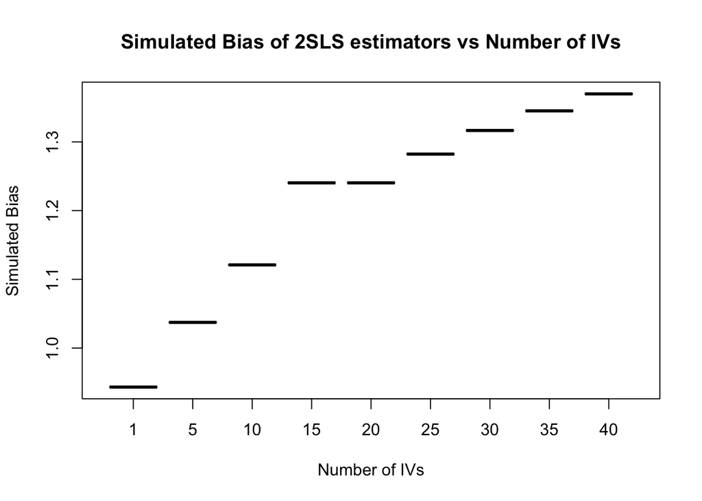

```r
# Create new data frame comprising of Simulated bias and number of IVs
plot_data <- cbind(c(1,5,10,15,20,25,30,35,40), simulated_bias)
plot_data <- as.data.frame((plot_data))

# plot simulated bias vs number of IVs
plot(as.factor(plot_data$V1),plot_data$V2,xlab="Number of IVs", ylab="Simulated Bias", main="Simulated Bias of 2SLS estimators vs Number of IVs")
```

Summary: The absolute value of Simulated Bias increases with the Number of IVs. Using many IVs does result in significant bias.